## Proyecto Final Data Science R - Carlos Eduardo Gomez Fandiño

Instalar cada biblioteca y habilitarla para el proyecto

```r
#install.packages("ggplot2", dependencies = TRUE)
#install.packages("gridExtra")
#install.packages("dplyr")
#install.packages("corrplot")
```

```r
library(ggplot2)
library(gridExtra)
library(dplyr)
library(corrplot)
```

1. Leer el fichero titanic.csv como un dataframe.

```r
titanic <- as.data.frame(read.table('titanic.csv', header= T, sep =','))

head(titanic)
```

```
##   PassengerId Survived Pclass
## 1           1        0      3
## 2           2        1      1
## 3           3        1      3
## 4           4        1      1
## 5           5        0      3
## 6           6        0      3
##                                                  Name    Sex Age SibSp
## 1                             Braund, Mr. Owen Harris   male  22     1
## 2 Cumings, Mrs. John Bradley (Florence Briggs Thayer) female  38     1
## 3                              Heikkinen, Miss. Laina female  26     0
## 4        Futrelle, Mrs. Jacques Heath (Lily May Peel) female  35     1
## 5                            Allen, Mr. William Henry   male  35     0
## 6                                    Moran, Mr. James   male  NA     0
##   Parch           Ticket    Fare Cabin Embarked
## 1     0        A/5 21171  7.2500              S
## 2     0         PC 17599 71.2833   C85        C
## 3     0 STON/O2. 3101282  7.9250              S
## 4     0           113803 53.1000  C123        S
## 5     0           373450  8.0500              S
## 6     0           330877  8.4583              Q
```

2. Calcular el porcentaje de pasajeros que sobrevivio.

```r
survipercent <- prop.table(table(titanic$Survived))

cat("Porcentaje Sobrevivientes:", survipercent[2]*100,'%')
```

```
## Porcentaje Sobrevivientes: 38.38384 %
```

3. Calcular el porcentaje de missing values en cada uno de los atributos. Pista: averiguar que devuelve la funcion is.na cuando se aplica a un dataframe.

```r
apply(titanic, 2, function(x) sum(is.na(x)))/length(titanic) # porcentaje de missing values
```

```
## PassengerId    Survived      Pclass        Name         Sex         Age
##        0.00        0.00        0.00        0.00        0.00       14.75
##       SibSp       Parch      Ticket        Fare       Cabin    Embarked
##        0.00        0.00        0.00        0.00        0.00        0.00
```

4. Eliminar la variable cabin del dataframe.

```r
titanic$Cabin <- NULL
head(titanic)
```

```
##   PassengerId Survived Pclass
## 1           1        0      3
## 2           2        1      1
## 3           3        1      3
## 4           4        1      1
## 5           5        0      3
## 6           6        0      3
##                                                  Name    Sex Age SibSp
## 1                             Braund, Mr. Owen Harris   male  22     1
## 2 Cumings, Mrs. John Bradley (Florence Briggs Thayer) female  38     1
## 3                              Heikkinen, Miss. Laina female  26     0
## 4        Futrelle, Mrs. Jacques Heath (Lily May Peel) female  35     1
## 5                            Allen, Mr. William Henry   male  35     0
## 6                                    Moran, Mr. James   male  NA     0
##   Parch           Ticket    Fare Embarked
## 1     0        A/5 21171  7.2500        S
## 2     0         PC 17599 71.2833        C
## 3     0 STON/O2. 3101282  7.9250        S
## 4     0           113803 53.1000        S
## 5     0           373450  8.0500        S
## 6     0           330877  8.4583        Q
```

5. Completar los missing values del atributo age con la mediana del resto de datos.

```r
titanic$Age[which(is.na(titanic$Age))] <- mean(titanic$Age, na.rm = T)
```

6. Calcular la probabilidad de supervivencia en base al genero. ¿Que conclusion(es) obtienes del resultado? Pista: dado que la variable survived toma el valor 1 cuando el pasajero sobrevivio, es sencillo calcular la probabilidad de supervivencia con una funcion estadistica.

```r
Sex <- summary(titanic$Sex)

probSurviSex <- prop.table(table(titanic$Sex, titanic$Survived),1) # Probabilidades sobrevive/Nosobrevive por sexos en una tabla resumida

probSurviSex[,2]*100 # probabilidad de supervivencia por Genero
```

```
##   female     male
## 74.20382 18.89081
```

6.2. Otra Forma de calcularlo

```r
Sex <- as.factor(titanic$Sex)
Survived <- as.factor(titanic$Survived)
sobrevive <- sum(titanic$Survived==1) # Numero sobrevivientes: 342
noSobrevive <- sum(titanic$Survived==0) #Numero de No sobrevivientes: 549
hombres <- sum(titanic$Sex=='male') # total hombres abordo: 577
mujeres <- sum(titanic$Sex=='female') # total mujeres abordo: 314

viveHombre <- sum(titanic$Survived==1 & titanic$Sex=='male') #total hombres sobrevivientes: 109
viveMujer <- sum(titanic$Survived==1 & titanic$Sex=='female') # total mujeres sobrevivientes: 233

probMaleVive <- viveHombre/hombres # Probabilidad sobrevive hombre: 18.89%
probFemaleVive <- viveMujer/mujeres # Probabilidad sobrevive mujer: 74.20%
```

Plot:

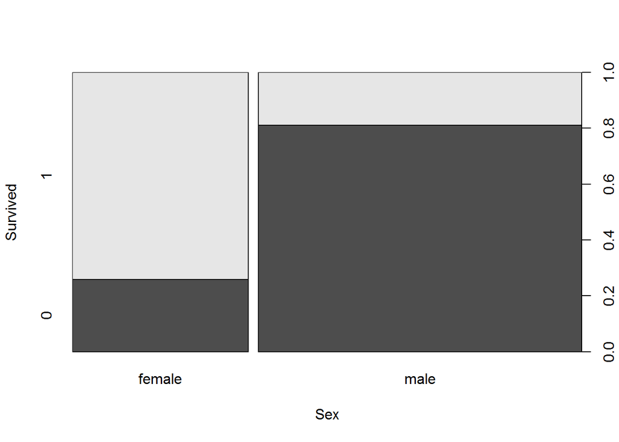

```r
plot(Sex, Survived, xlab='Sex',ylab='Survived') #Ploting Sex vs. Survived
```

7. Calcular la probabilidad de supervivencia en base a la edad. ¿Te parecen facilmente interpretables estos resultados

```r
summary(titanic$Age)
```

```
##    Min. 1st Qu.  Median    Mean 3rd Qu.    Max.
##    0.42   22.00   29.70   29.70   35.00   80.00
```

```r
tabla.edad <- prop.table(table(titanic$Age<30,titanic$Survived),1)

probSurviLess30 <- tabla.edad[2,2]
probSurviOver30 <- tabla.edad[1,2]

cat('Probabilidad sobrevivir menor a 30 años es: ',probSurviLess30*100,'%','\n','Probabilidad sobrevivir mayor o igual a 30 años es:', probSurviOver30*100, '%')
```

```
## Probabilidad sobrevivir menor a 30 años es:  37.07665 %
##  Probabilidad sobrevivir mayor o igual a 30 años es: 40.60606 %
```

8. Crea una nueva variable decade en el dataframe que contenga la decada de la edad de los pasajeros y repite el analisis del apartado g) sobre esta nueva variable.¿Que conclusion(es) obtienes del resultado?

```r
summary(titanic$Age)
```

```
##    Min. 1st Qu.  Median    Mean 3rd Qu.    Max.
##    0.42   22.00   29.70   29.70   35.00   80.00
```

```r
titanic$decade <- if_else(titanic$Age<10,0, if_else(titanic$Age<20,1, if_else(titanic$Age<30,2, if_else(titanic$Age<40,3, if_else(titanic$Age<50,4, if_else(titanic$Age<60,5, if_else(titanic$Age<70,6,if_else(titanic$Age<80,7,if_else(titanic$Age<90,8,9)))))))))

#titanic[,c('Age','decade')] #comprobacion

decade <- as.factor(titanic$decade)

probSurviDecade <- prop.table(table(decade,Survived),1)

probSurviDecade[,2] # Probabilidad de Supervivienvia por Decade
```

```
##         0         1         2         3         4         5         6
## 0.6129032 0.4019608 0.3249370 0.4371257 0.3820225 0.4166667 0.3157895
##         7         8
## 0.0000000 1.0000000
```

agrupacion de sobrevivientes por cada grupo de decada

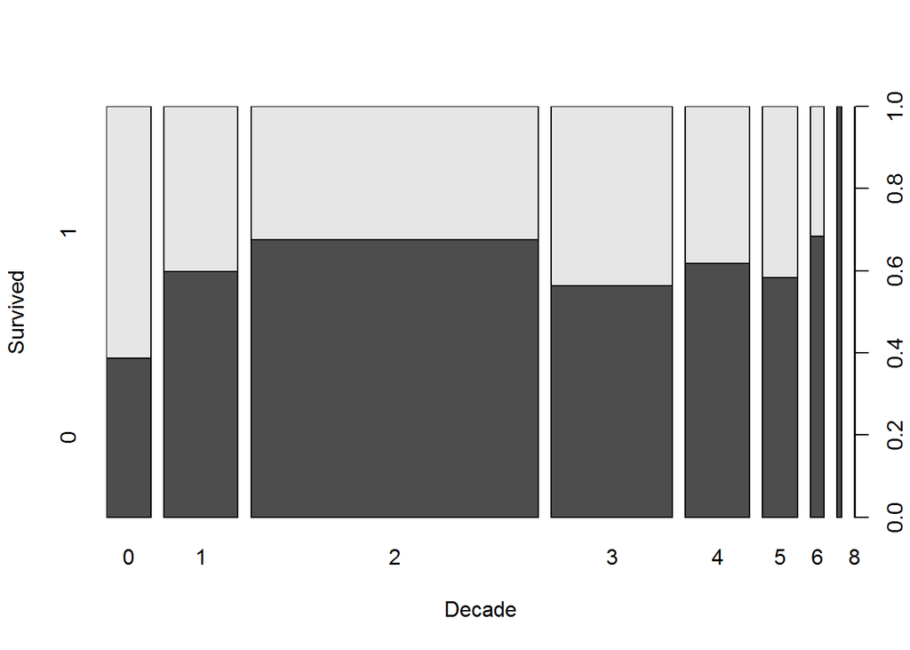

```r
plot(decade, Survived, xlab='Decade',ylab='Survived') #Ploting decade vs, survived
```

9. Calcula la probabilidad de supervivencia en base a la clase del billete del pasajero (pclass). ¿Que conclusion(es) obtienes del resultado?

```r
summary(titanic$Pclass)
```

```
##    Min. 1st Qu.  Median    Mean 3rd Qu.    Max.
##   1.000   2.000   3.000   2.309   3.000   3.000
```

```r
Pclass <- as.factor(titanic$Pclass)

probSurviClass <- prop.table(table(titanic$Pclass,titanic$Survived),1)

probSurviClass1 <- probSurviClass[1,2] # Probabilidad superviviencia clase 1: 62.96%
probSurviClass2 <- probSurviClass[2,2] # Probabilidad superviviencia clase 2: 47.28%
probSurviClass3 <- probSurviClass[3,2] # Probabilidad superviviencia clase 3: 24.23%


cat(' Probabilidad sobrevivir clase1: ', probSurviClass1*100,'%', '\n', 'Probabilidad sobrevivir clase2: ', probSurviClass2*100,'%', '\n', 'Probabilidad sobrevivir clase3: ', probSurviClass3*100,'%')
```

```
##  Probabilidad sobrevivir clase1:  62.96296 %
##  Probabilidad sobrevivir clase2:  47.28261 %
##  Probabilidad sobrevivir clase3:  24.23625 %
```

Plot:

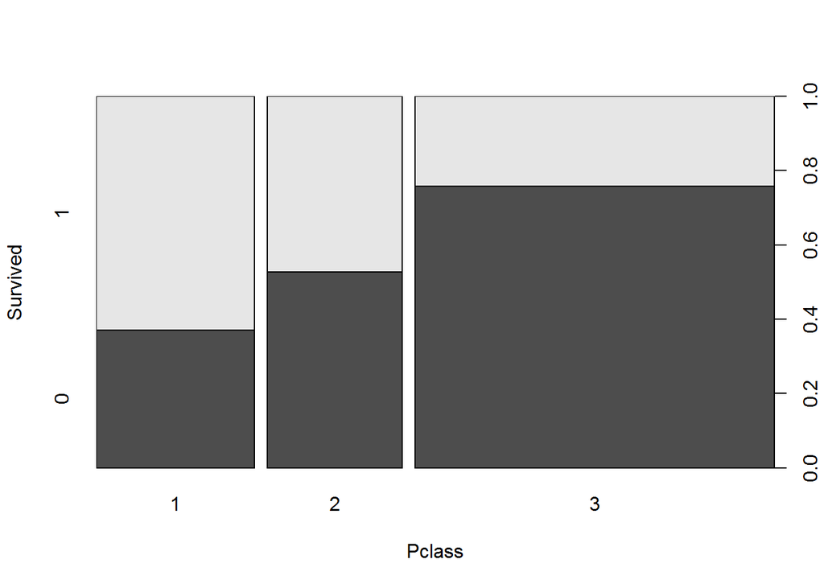

```r
plot(Pclass,Survived, xlab='Pclass',ylab='Survived') # Ploting la clase vs. la superviviencia
```

Respuesta: La probabilidad de superviviencia de la clase 1: 62.96%, Clase 2: 47.28%, Clase 3: 24.23%

10. Combina en una tabla el analisis de la probabilidad de supervivencia en base al sexo y clase del billete del pasajero. ¿Que conclusiones se obtienen?

```r
probSurviSexClass <- prop.table(table(Sex,Pclass,by=Survived))

probSurviSexClass[,,2]*100 #Probabilidad de superviviencia en base al sexo y clase
```

```
##         Pclass
## Sex              1         2         3
##   female 10.213244  7.856341  8.080808
##   male    5.050505  1.907969  5.274972
```

Respuesta: sacamos la conclucion que las mujeres de clase1 tuvieron mayor probabilidad de supervivencia., mientras que los hombres de clase 1 y 3 tuvueron la misma probabilidad de sobrevivir.

11. Crea dos nuevas variables en el dataframe con la siguiente informacion:
- familysize: numero total de parientes incluyendo al propio pasajero.
- sigleton: valor logico indicando con valor TRUE si el pasajero viaja solo y FALSE en caso contrario.

```r
titanic$familysize <- titanic$Parch + titanic$SibSp +1
titanic$sigleron <- if_else(titanic$familysize==1, 1 , 0)
```

12. Calcula la probabilidad de supervivencia en base a si el pasajero viajaba solo o no. ¿Que conclusion se puede obtener?

```r
sigleron <- as.factor(titanic$sigleron)

probSurviSigleron <-prop.table(table(sigleron, Survived))

probSurviSigleron[,2]*100 # Probabilidad de Supervivencia segun si viajaba solo o no
```

```
##        0        1
## 20.08979 18.29405
```

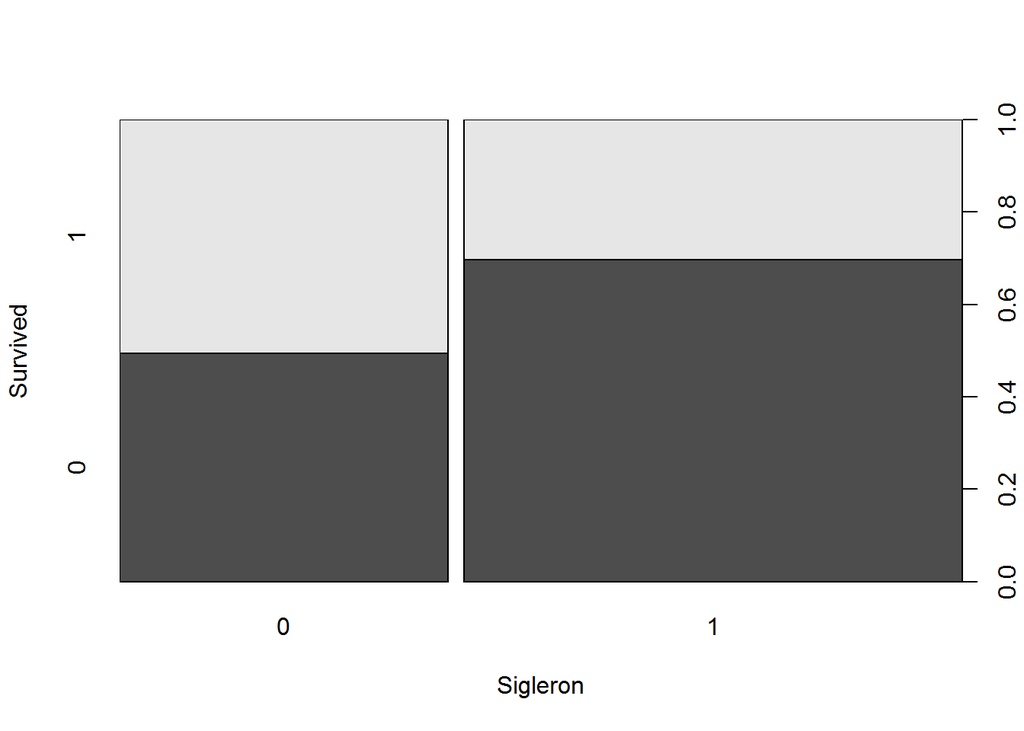

```r
plot(sigleron, Survived, xlab='Sigleron',ylab='Survived') #Ploting prob supervivienvia 'sigleron'
```

13. Cuenta el numero de pasajeros por tamaño de familia y clase. Por ejemplo, cuantos pasajeros de primera clase pertenecen a una familia de tamaño 4. El resultado debe ser una matriz con la informacion para todas las posibles combinaciones de clase del billete y tamaño de familia.

```r
familysize <- as.factor(titanic$familysize)

table(familysize,Pclass) # matriz tamaño de familia vs clase
```

```
##           Pclass
## familysize   1   2   3
##         1  109 104 324
##         2   70  34  57
##         3   24  31  47
##         4    7  13   9
##         5    2   1  12
##         6    4   1  17
##         7    0   0  12
##         8    0   0   6
##         11   0   0   7
```

14. Leer el fichero titanic2.csv, que contiene informacion adicional sobre los pasajeros del barco:
- boat: identicador del bote salvavidas
- body: identicador del cuerpo
- home.dest: Origen/destino

```r
titanic2 <- as.data.frame(read.csv2('titanic2.csv',header = T))
```

15. Para unicar estos dos datraframes, parecera buena opcion utilizar la variable name como clave. Determina si esta variable es unica por pasajero utilizando la funcion duplicated o unique y mostrando el numero de nombres diferentes repetidos. En caso de existir varios pasajeros con el mismo nombre, listar aquellas las del dataframe inicial en las que el nombre del pasajero este repetido (la funcion %in% puede resultar util para ello). De acuerdo a los resultados, ¿sera la combinacion del nombre del pasajero y la clase una buena clave para combinar los dataframes? Combina ambos dataframes utilizando la combinacion del nombre y el numero de billete respetando el orden de los dataframes de partida. Pista: funcion merge.

```r
titanic3 <- merge(x = titanic, y = titanic2, by.x =c('Name','Ticket'),by.y =c('name','ticket'), all.x = TRUE)

head(titanic3)
```

```
##                                    Name    Ticket PassengerId Survived
## 1                   Abbing, Mr. Anthony C.A. 5547         846        0
## 2           Abbott, Mr. Rossmore Edward C.A. 2673         747        0
## 3      Abbott, Mrs. Stanton (Rosa Hunt) C.A. 2673         280        1
## 4                   Abelson, Mr. Samuel P/PP 3381         309        0
## 5 Abelson, Mrs. Samuel (Hannah Wizosky) P/PP 3381         875        1
## 6        Adahl, Mr. Mauritz Nils Martin    C 7076         366        0
##   Pclass    Sex Age SibSp Parch  Fare Embarked decade familysize sigleron
## 1      3   male  42     0     0  7.55        S      4          1        1
## 2      3   male  16     1     1 20.25        S      1          3        0
## 3      3 female  35     1     1 20.25        S      3          3        0
## 4      2   male  30     1     0 24.00        C      3          2        0
## 5      2 female  28     1     0 24.00        C      2          2        0
## 6      3   male  30     0     0  7.25        S      3          1        1
##   boat body                   home.dest
## 1        NA
## 2       190         East Providence, RI
## 3    A   NA         East Providence, RI
## 4        NA         Russia New York, NY
## 5   10   NA         Russia New York, NY
## 6        72 Asarum, Sweden Brooklyn, NY
```

16. ¿Qué porcentaje de los pasajeros que sobrevivió tiene asociado un identificador del bote salvavidas?

```r
table.prop.surv <- prop.table(table(titanic3$boat != '', titanic3$Survived),2)
cat('La probabilidad de supervivincia de un pasajero que tenia asociado un identificador de bote salvadidas es de: ', table.prop.surv[2,2]*100, '%')
```

```
## La probabilidad de supervivincia de un pasajero que tenia asociado un identificador de bote salvadidas es de:  94.73684 %
```

### Parte 2 Con el conjunto de datos diabetes.data:

1. Cargar los datos en un dataframe de R y eliminar los missing values,que estan codicados como -9999.00.

```r
diabetes <- as.data.frame(read.table('diabetes.data', header = T))
head(diabetes)
```

```
##   AGE SEX  BMI  BP  S1    S2 S3 S4     S5 S6   Y
## 1  59   F 32.1 101 157  93.2 38  4 4.8598 87 151
## 2  48   M 21.6  87 183 103.2 70  3 3.8918 69  75
## 3  72   F 30.5  93 156  93.6 41  4 4.6728 85 141
## 4  24   M 25.3  84 198 131.4 40  5 4.8903 89 206
## 5  50   M 23.0 101 192 125.4 52  4 4.2905 80 135
## 6  23   M 22.6  89 139  64.8 61  2 4.1897 68  97
```

```r
diabetes <- diabetes[diabetes$BMI>0 & diabetes$BP>0 & diabetes$S2>0 & diabetes$S5>0 ,]
```

2. Ver el tipo de cada una de las variables.

```r
str(diabetes) #tipo de variable de cada columna
```

```
## 'data.frame':    433 obs. of  11 variables:
##  $ AGE: int  59 48 72 24 50 23 36 66 60 29 ...
##  $ SEX: Factor w/ 2 levels "F","M": 1 2 1 2 2 2 1 1 1 2 ...
##  $ BMI: num  32.1 21.6 30.5 25.3 23 22.6 22 26.2 32.1 30 ...
##  $ BP : num  101 87 93 84 101 89 90 114 83 85 ...
##  $ S1 : int  157 183 156 198 192 139 160 255 179 180 ...
##  $ S2 : num  93.2 103.2 93.6 131.4 125.4 ...
##  $ S3 : num  38 70 41 40 52 61 50 56 42 43 ...
##  $ S4 : num  4 3 4 5 4 2 3 4.55 4 4 ...
##  $ S5 : num  4.86 3.89 4.67 4.89 4.29 ...
##  $ S6 : int  87 69 85 89 80 68 82 92 94 88 ...
##  $ Y  : int  151 75 141 206 135 97 138 63 110 310 ...
```

3. Realizar un analisis estadistico de las variables numericas: calcular la media, varianza, rangos, etc. ¿Tienen las distintas variables rangos muy diferentes?.

```r
diabetes2 <- diabetes[,-c(diabetes$SEX)]
summadiabetes <- sapply(diabetes2,summary) #calulos media, mediana, max, min, 1Quartil, 3Quartil
sapply(diabetes2,var) #calculo de las varianzas
```

```
##          BMI           BP           S1           S2           S3
##   19.6089824  194.2240393 1210.2951629  936.8608596  169.9568204
##           S4           S5           S6            Y
##    1.6894878    0.2757557  131.6506073 6013.5473441
```

R/: Todas la variables presentan rangos muy difertentes.

4. Hacer un grafico de cajas (boxplot) donde se pueda ver la informacion anterior de forma grafica.

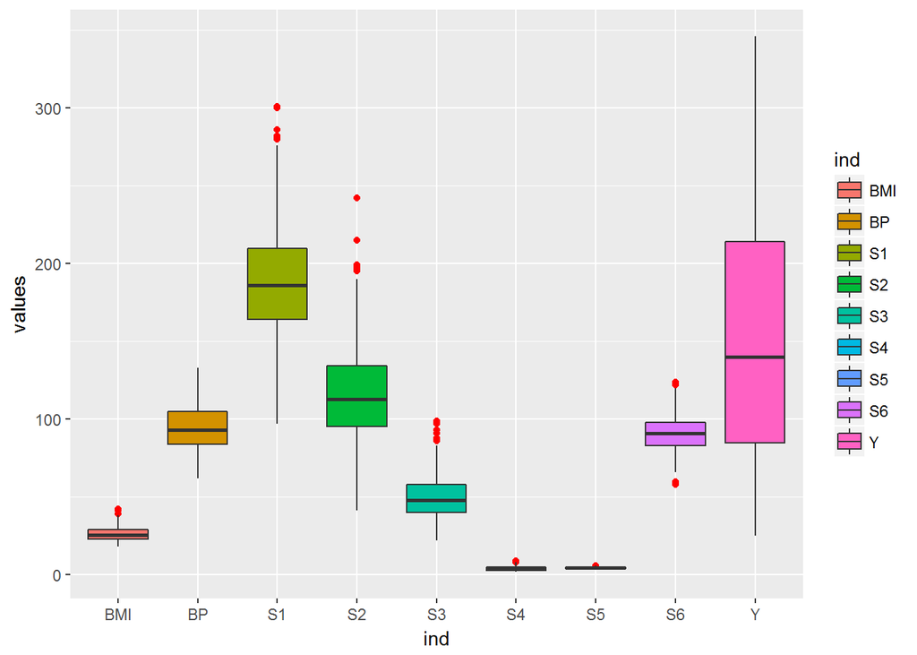

```r
ggplot(stack(diabetes2),aes(x=ind,y=values))+geom_boxplot(aes(fill=ind),outlier.colour = 'Red')
```

5. Calcular la media para las filas que tienen SEX=M y la media para las filas que tienen SEX=F, utilizando la funcion tapply.

```r
sex <- as.factor(diabetes$SEX)

BMImean <- tapply(diabetes$BMI, diabetes$SEX, mean)
BPmean <- tapply(diabetes$BP, diabetes$SEX, mean)
S1mean <- tapply(diabetes$S1, diabetes$SEX, mean)
S2mean <- tapply(diabetes$S2, diabetes$SEX, mean)
S3mean <- tapply(diabetes$S3, diabetes$SEX, mean)
S4mean <- tapply(diabetes$S4, diabetes$SEX, mean)
S5mean <- tapply(diabetes$S5, diabetes$SEX, mean)
S6mean <- tapply(diabetes$S6, diabetes$SEX, mean)
Ymean <- tapply(diabetes$Y, diabetes$SEX, mean)
```

Resumiento lo anterior en una linea de codigo

```r
tableMean <- aggregate(diabetes[,-c(diabetes$SEX)],by=list(diabetes$SEX), mean)
tableMean
```

```
##   Group.1      BMI       BP       S1       S2       S3       S4       S5
## 1       F 26.80099 98.17562 190.6552 120.1103 44.54187 4.537882 4.731533
## 2       M 25.95609 91.53474 188.0304 111.1726 54.56304 3.658217 4.569392
##         S6        Y
## 1 93.86207 155.8079
## 2 88.94348 149.0391
```

6. Calcular la correlacion de todas las variables numericas con la variable Y

```r
corrTable <- cor(diabetes2)
corrTable[,9] #Tabla correlacion de cada variable respecto a Y
```

```
##        BMI         BP         S1         S2         S3         S4
##  0.5863673  0.4398515  0.2133325  0.1747189 -0.3963076  0.4325640
##         S5         S6          Y
##  0.5703164  0.3892246  1.0000000
```

Otra forma de tener la correlacion

```r
apply(diabetes2,2, function(col) cor(col, diabetes2$Y))
```

```
##        BMI         BP         S1         S2         S3         S4
##  0.5863673  0.4398515  0.2133325  0.1747189 -0.3963076  0.4325640
##         S5         S6          Y
##  0.5703164  0.3892246  1.0000000
```

7. Realizar un grafico de dispersion para las variables que tienen mas y menos correlacion con Y y comentar los resultados. ¿Como seria el grafico de dispersion entre dos vectores con correlacion 1?.

```r
BMIY <- ggplot(diabetes2,aes(BMI,Y)) + geom_point()
BPY <- ggplot(diabetes2,aes(BP,Y)) + geom_point()
S1Y <- ggplot(diabetes2,aes(S1,Y)) + geom_point()
S2Y <- ggplot(diabetes2,aes(S2,Y)) + geom_point()
S3Y <- ggplot(diabetes2,aes(S3,Y)) + geom_point()
S4Y <- ggplot(diabetes2,aes(S4,Y)) + geom_point()
S5Y <- ggplot(diabetes2,aes(S5,Y)) + geom_point()
S6Y <- ggplot(diabetes2,aes(S6,Y)) + geom_point()
YY <- ggplot(diabetes2,aes(Y,Y)) + geom_point()
```

se debera intalar la biblioteca gridExtra

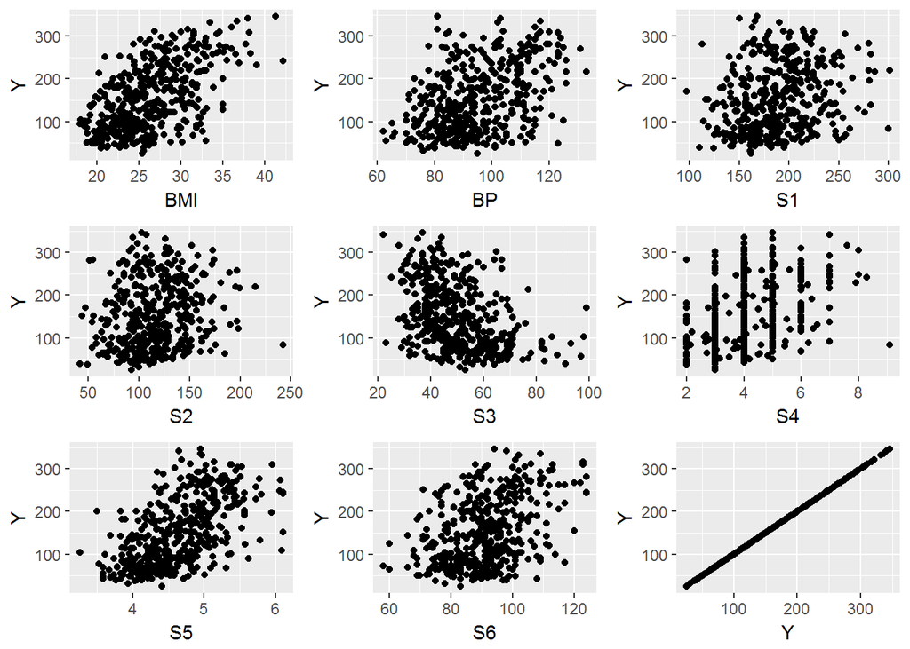

```r
grid.arrange(BMIY, BPY, S1Y, S2Y, S3Y, S4Y, S5Y, S6Y, YY,ncol=3) #multiples plot de dispercion.
```

```r
diacorr <- cor(diabetes2[,c(1:8)])
```

Gráfico correlación:

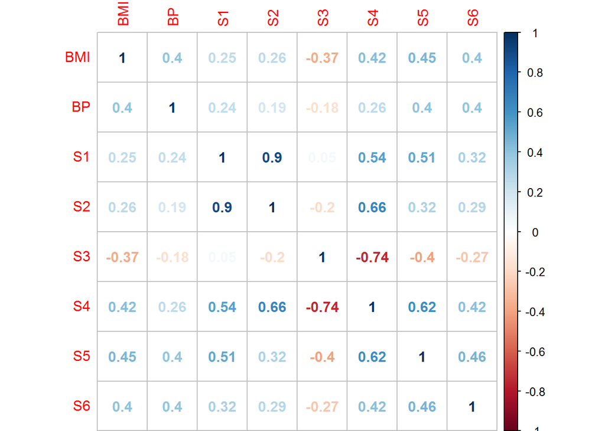

```r
corrplot(diacorr,method = 'number')
```

Transformar la variable SEX, que es un factor, en una variable numerica utilizando, por ejemplo, la codicacion M=1 y F=2.

```r
diabetes$Sex2<- as.numeric(factor(diabetes$SEX,levels = c('M','F')))
head(diabetes)
```

```
##   AGE SEX  BMI  BP  S1    S2 S3 S4     S5 S6   Y Sex2
## 1  59   F 32.1 101 157  93.2 38  4 4.8598 87 151    2
## 2  48   M 21.6  87 183 103.2 70  3 3.8918 69  75    1
## 3  72   F 30.5  93 156  93.6 41  4 4.6728 85 141    2
## 4  24   M 25.3  84 198 131.4 40  5 4.8903 89 206    1
## 5  50   M 23.0 101 192 125.4 52  4 4.2905 80 135    1
## 6  23   M 22.6  89 139  64.8 61  2 4.1897 68  97    1
```

9. Definimos los outliers como los elementos (filas) de los datos para los que cualquiera de las variables (numericas) esta por encima o por debajo de la mediana mas/menos 3 veces el MAD (Median Absolute Deviation). Identificar estos outliers y quitarlos.

```r
diabetes.summary <- apply(diabetes2,2,summary)

diabetes.median <- diabetes.summary[3,]

diabetes.mad <- apply(diabetes2,2,mad)

diabetes.median
```

```
##     BMI      BP      S1      S2      S3      S4      S5      S6       Y
##  25.700  93.000 186.000 113.000  48.000   4.000   4.635  91.000 140.000
```

```r
diabetes.mad
```

```
##        BMI         BP         S1         S2         S3         S4
##  4.2995400 14.8260000 34.0998000 28.4659200 13.3434000  1.4826000
##         S5         S6          Y
##  0.5374425 10.3782000 88.9560000
```

10. Separar el conjunto de datos en dos subconjuntos disjuntos de forma aleatoria, el primero conteniendo un 70% de los datos y el segundo un 30%.

```r
primer.contenido <- sample_frac(diabetes2, 0.7)
segundo.contenido <- setdiff(diabetes2, primer.contenido)
```

11. Escalar los datos para que tengan media 0 y varianza 1, es decir, restar a cada variable numerica su media y dividir por la desviacion típica.

```r
diabetes.escalado <- apply(diabetes2, 2, function(x) (x-mean(x))/sd(x))
head(diabetes.escalado)
```

```
##          BMI         BP          S1         S2         S3          S4
## 1  1.2979996  0.4557746 -0.92732458 -0.7240815 -0.9101116 -0.05433405
## 2 -1.0731653 -0.5487869 -0.17996828 -0.3973714  1.5444881 -0.82368141
## 3  0.9366793 -0.1182605 -0.95606905 -0.7110131 -0.6799929 -0.05433405
## 4 -0.2376120 -0.7640501  0.25119881  0.5239508 -0.7566991  0.71501332
## 5 -0.7570100  0.4557746  0.07873197  0.3279248  0.1637758 -0.05433405
## 6 -0.8473401 -0.4052781 -1.44472510 -1.6519379  0.8541320 -1.59302877
##            S5         S6           Y
## 1  0.40827055 -0.3703552 -0.01563529
## 2 -1.43510207 -1.9391317 -0.99568528
## 3  0.05216448 -0.5446637 -0.14458924
## 4  0.46635202 -0.1960467  0.69361140
## 5 -0.67585345 -0.9804350 -0.22196161
## 6 -0.86780795 -2.0262860 -0.71198660
```

Media diabetes escalado:

```r
round(apply(diabetes.escalado,2,mean),0) # comprobacion media = 0, dataset diabetes2
```

```
## BMI  BP  S1  S2  S3  S4  S5  S6   Y
##   0   0   0   0   0   0   0   0   0
```

desviacion diabetes escalado:

```r
apply(diabetes.escalado,2,sd) # comprobacion desviacion = 1, del dataset diabetes2
```

```
## BMI  BP  S1  S2  S3  S4  S5  S6   Y
##   1   1   1   1   1   1   1   1   1
```

Calcular la media y desviacion en el conjunto de train, y utilizar esa misma media y desviacion para escalar el conjunto de test.

```r
p.c.mean <- apply(primer.contenido,2,mean)
p.c.sd <- apply(primer.contenido,2,sd)

segundo.contenido.escalado <- (segundo.contenido - matrix(p.c.mean, nrow(segundo.contenido), ncol(segundo.contenido),byrow = T))/matrix(p.c.sd, nrow(segundo.contenido), ncol(segundo.contenido),byrow = T)

s.c.escalado.media <- apply(segundo.contenido.escalado,2,mean)
s.c.escalado.sd <- apply(segundo.contenido.escalado,2,sd)
```

media segundo contenido (test) escalado

```r
s.c.escalado.media
```

```
##         BMI          BP          S1          S2          S3          S4
##  0.03663692  0.06750297  0.06630226  0.08266154 -0.03242181  0.04698035
##          S5          S6           Y
## -0.01126357 -0.01491834  0.01414921
```

desviacion segundo contenido test escalado

```r
s.c.escalado.sd
```

```
##       BMI        BP        S1        S2        S3        S4        S5
## 1.1260248 0.9837751 1.0143901 1.0048242 0.9612363 1.0427916 1.0362469
##        S6         Y
## 1.0351463 1.0183680
```